# LASSO Regression using Package glmnet

# **4. 데이터 분할**

```r
# Partition (Training Dataset : Test Dataset = 7:3)
y      <- UB$Personal.Loan                            # Target

set.seed(200)
ind    <- createDataPartition(y, p = 0.7, list = T)   # Index를 이용하여 7:3으로 분할
UB.trd <- UB[ind$Resample1,]                          # Training Dataset
UB.ted <- UB[-ind$Resample1,]                         # Test Dataset
```

# **5. 데이터 전처리 II**

```r
# 1. Standardization
preProcValues <- preProcess(UB.trd,
                            method = c("center", "scale"))  # Training Dataset에 대한 평균과 표준편차 계산

UB.trd <- predict(preProcValues, UB.trd)                    # 표준화 for Training Dataset
UB.ted <- predict(preProcValues, UB.ted)                    # 표준화 for Test Dataset

glimpse(UB.trd)                                             # 데이터 구조 확인
```

```
Rows: 1,751
Columns: 13
$ Age                <dbl> -0.05431273, -0.57446728, -0.92123699, -0…
$ Experience         <dbl> -0.12175295, -0.46882565, -0.98943471, -1…
$ Income             <dbl> -0.85867297, -1.35649686, 0.56986515, -0.…
$ ZIP.Code           <dbl> -1.75250883, 0.88354520, 0.53745994, -1.0…
$ Family             <fct> 3, 1, 1, 4, 2, 1, 3, 1, 4, 3, 2, 4, 1, 4,…
$ CCAvg              <dbl> -0.25119120, -0.53150921, 0.42157204, -0.…
$ Education          <fct> 1, 1, 2, 2, 2, 3, 2, 3, 3, 2, 3, 2, 1, 3,…
$ Mortgage           <dbl> -0.5664192, -0.5664192, -0.5664192, -0.56…
$ Personal.Loan      <fct> no, no, no, no, no, no, no, yes, no, no, …
$ Securities.Account <fct> 1, 0, 0, 0, 0, 0, 0, 0, 0, 0, 1, 0, 1, 0,…
$ CD.Account         <fct> 0, 0, 0, 0, 0, 0, 0, 0, 0, 0, 0, 0, 0, 0,…
$ Online             <fct> 0, 0, 0, 0, 1, 0, 1, 0, 0, 1, 0, 1, 0, 0,…
$ CreditCard         <fct> 0, 0, 0, 1, 0, 1, 0, 0, 0, 0, 0, 0, 0, 0,…
```

```r
glimpse(UB.ted)                                             # 데이터 구조 확인
```

```
Rows: 749
Columns: 13
$ Age                <dbl> -1.7881612, -0.7478521, 1.2460737, 0.8126…
$ Experience         <dbl> -1.68358012, -0.64236200, 0.83269699, 0.6…
$ Income             <dbl> -0.53400522, -0.96689556, -1.11840718, -1…
$ ZIP.Code           <dbl> -1.17304370, -0.59585545, 1.07366441, 0.8…
$ Family             <fct> 4, 4, 1, 1, 4, 1, 4, 4, 3, 3, 1, 3, 1, 4,…
$ CCAvg              <dbl> -0.19512759, -0.86789083, -0.25119120, -0…
$ Education          <fct> 1, 2, 3, 2, 2, 3, 3, 3, 3, 2, 1, 2, 1, 2,…
$ Mortgage           <dbl> -0.5664192, 0.9609885, -0.5664192, -0.566…
$ Personal.Loan      <fct> no, no, no, no, no, no, no, no, no, no, n…
$ Securities.Account <fct> 1, 0, 0, 1, 0, 0, 0, 0, 1, 0, 0, 1, 1, 0,…
$ CD.Account         <fct> 0, 0, 0, 0, 0, 0, 0, 0, 0, 0, 0, 1, 0, 0,…
$ Online             <fct> 0, 1, 1, 0, 1, 1, 1, 1, 0, 1, 1, 1, 0, 1,…
$ CreditCard         <fct> 0, 0, 1, 1, 0, 1, 0, 0, 0, 0, 0, 0, 0, 0,…
```

```r
# 2. Convert Factor Var. into Dummy Var.
train.x <- model.matrix(Personal.Loan ~.,                   # Personal.Loan은 Target으로 제외
                        UB.trd)[,-1]                        # [,-1] : 절편 제거

train.x
```

```
             Age  Experience       Income    ZIP.Code Family2 Family3
2    -0.05431273 -0.12175295 -0.858672972 -1.75250883       0       1
3    -0.57446728 -0.46882565 -1.356496863  0.88354520       0       0
4    -0.92123699 -0.98943471  0.569865150  0.53745994       0       0
5    -0.92123699 -1.07620288 -0.620583285 -1.04610783       0       0
7     0.63922667  0.57239246 -0.036181326 -0.82923532       1       0
8     0.37914940  0.31208793 -1.118407176  0.44126189       0       0
9    -0.92123699 -0.90266653  0.158619327 -1.75250883       0       1
10   -1.00792941 -0.98943471  2.301426510 -0.08241975       0       0
11    1.67953578  1.61361058  0.678087735  0.87785301       0       0
12   -1.44139154 -1.33650741 -0.620583285 -1.64549562       0       1
13    0.20576455  0.22531976  0.872888388 -0.03517456       1       0
14    1.15938123  1.00623334 -0.728805870  0.99738903       0       0
15    1.85292063  1.78714693  0.829599354 -0.81215874       0       0
17   -0.66115971 -0.55559383  1.219200660  1.04861876       0       0
```

[output cut: 5241 more lines]

```r
test.x <- model.matrix(Personal.Loan ~.,                    # Personal.Loan은 Target으로 제외
                       UB.ted)[,-1]                         # [,-1] : 절편 제거

test.x
```

```
             Age  Experience       Income     ZIP.Code Family2
1    -1.78816124 -1.68358012 -0.534005217  -1.17304370       0
6    -0.74785214 -0.64236200 -0.966895557  -0.59585545       0
16    1.24607365  0.83269699 -1.118407176   1.07366441       0
20    0.81261153  0.65916064 -1.140051693   0.88354520       0
21    0.89930395  0.91946517 -1.053473625   0.48224568       0
29    0.89930395  0.83269699 -0.555649734   0.78051653       0
35   -1.26800669 -1.33650741 -0.512360700   0.49363006       0
40   -0.66115971 -0.64236200  0.136974810   0.53916759       0
41    0.98599638  1.00623334  0.223552878  -0.28221568       0
47   -0.57446728 -0.55559383 -0.663872319   1.05089564       0
52    1.33276608  1.44007422  1.240845177   0.88354520       0
57    0.81261153  0.83269699 -0.966895557   0.47655348       0
62    0.11907212  0.05178341  1.110978075   0.13616041       0
64   -0.31439001 -0.29528930 -0.901962006   0.77140902       0
```

[output cut: 2235 more lines]

# **6. 모형 훈련**

Package `"glmnet"`에서 제공하는 함수 `glmnet()`을 이용하여 `LASSO Regression`을 수행할 수 있다. 함수 `glmnet()`는 Target이 2개의 클래스를 가질 때 “두 번째 클래스”에 속할 확률을 모델링하며, “두 번째 클래스”란 “Factor” 변환하였을 때 두 번째 수준(Level)을 의미한다. 예를 들어, “a”와 “b” 2개의 클래스를 가진 Target을 “Factor” 변환하였을 때 수준이 “a” “b”라면, 첫 번째 클래스는 “a”, 두 번째 클래스는 “b”가 된다. 함수 `glmnet()`에 대한 자세한 옵션은 [여기](https://www.rdocumentation.org/packages/glmnet/versions/4.1-8/topics/glmnet)를 참고한다.

```r
glmnet(x, y, family, alpha, lambda, ...)
```

- `x` : 예측 변수를 포함하는 행렬
- `y` : Target을 포함하는 변수
- `family` : Target의 분포
  - `"gaussian"` : 수치형인 Target
  - `"binomial"` : 2개의 클래스를 가지는 Target
  - `"multinomial"` : 3개 이상 클래스를 가지는 Target
  - `"poisson"` : Count Data인 Target
- `alpha` : Elasticnet Mixing Parameter
  - `0` : Ridge Regression
  - `1` : Lasso Regression
  - `0 < alpha < 1` : Elastic Net Regression
- `lambda` : Regularization Parameter
  - 직접 값을 지정하면 해당 값에 대한 결과만 보여준다.
  - 값을 지정하지 않으면 100개의 `lambda` 값에 대한 결과를 보여준다.

## **6-1. 람다 값 직접 지정**

```r
lasso.fit <- glmnet(x = train.x,                 # 예측 변수를 포함하는 행렬
                    y = UB.trd$Personal.Loan,    # Target
                    family = "binomial",         # Binary Classification
                    alpha = 1,                   # 0 : Ridge / 1 : Lasso / 0 < alpha < 1 : Elastic Net
                    lambda = 0.1)

round(coef(lasso.fit), 3)                        # 회귀계수 추정치
```

```
16 x 1 sparse Matrix of class "dgCMatrix"
                        s0
(Intercept)         -2.300
Age                  .
Experience           .
Income               0.564
ZIP.Code             .
Family2              .
Family3              .
Family4              .
CCAvg                .
Education2           .
Education3           .
Mortgage             .
Securities.Account1  .
CD.Account1          .
Online1              .
CreditCard1          .
```

`Result!` 데이터 “UB.trd”의 Target “Personal.Loan”은 “no”와 “yes” 2개의 클래스를 가지며, “Factor” 변환하면 알파벳순으로 수준을 부여하기 때문에 “yes”가 두 번째 클래스가 된다. 즉, “yes”에 속할 확률(= 개인 대출 제의를 수락할 확률)을 $p$라고 할 때, 추정된 회귀계수를 이용하여 다음과 같은 모형식을 얻을 수 있다.
$$\begin{align*}
\log{\frac{p}{1-p}} = &-2.300 + 0.564 Z_{\text{Income}}
\end{align*}$$
여기서, $Z_{\text{예측 변수}}$는 표준화한 예측 변수를 의미한다.

## **6-2. 교차 검증을 통한 최적의 람다 값**

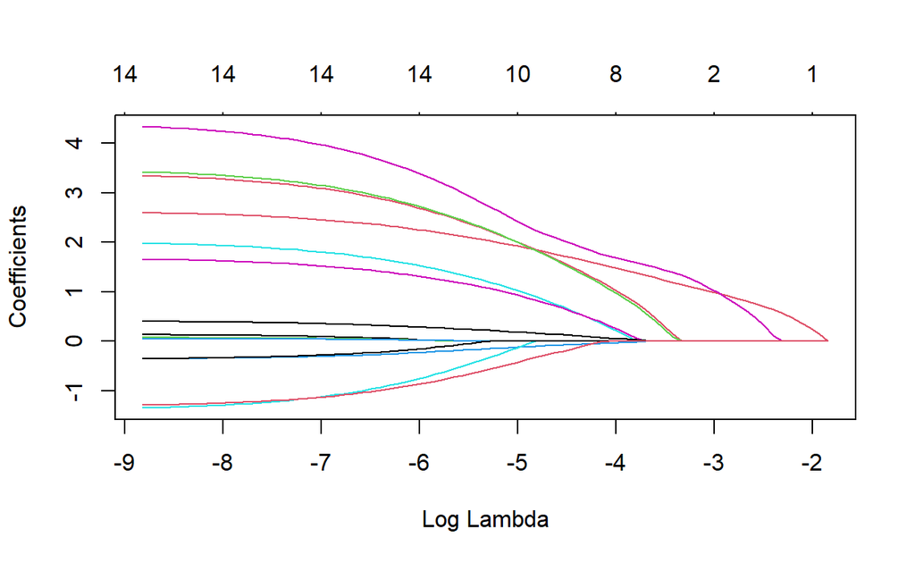

```r
# 100개의 람다 값에 따른 결과
lasso.fit <- glmnet(x = train.x,                 # 예측 변수를 포함하는 행렬
                    y = UB.trd$Personal.Loan,    # Target
                    family = "binomial",         # Binary Classification
                    alpha = 1)                   # 0 : Ridge / 1 : Lasso / 0 < alpha < 1 : Elastic Net

plot(lasso.fit, xvar = "lambda")                 # 람다 값에 따른 회귀계수 추정치 확인
```

```r
lasso.fit$lambda                                 # 100개의 람다 값
```

```
 [1] 0.1591853095 0.1450437253 0.1321584405 0.1204178489 0.1097202591
 [6] 0.0999730137 0.0910916867 0.0829993523 0.0756259186 0.0689075204
[11] 0.0627859662 0.0572082340 0.0521260122 0.0474952809 0.0432759311
[16] 0.0394314166 0.0359284383 0.0327366548 0.0298284206 0.0271785460
[21] 0.0247640788 0.0225641063 0.0205595733 0.0187331175 0.0170689190
[26] 0.0155525632 0.0141709164 0.0129120112 0.0117649437 0.0107197786
[31] 0.0097674630 0.0088997485 0.0081091194 0.0073887275 0.0067323334
[36] 0.0061342514 0.0055893014 0.0050927633 0.0046403362 0.0042281016
[41] 0.0038524887 0.0035102442 0.0031984038 0.0029142664 0.0026553710
[46] 0.0024194752 0.0022045357 0.0020086908 0.0018302442 0.0016676504
[51] 0.0015195009 0.0013845126 0.0012615164 0.0011494467 0.0010473330
[56] 0.0009542909 0.0008695143 0.0007922690 0.0007218860 0.0006577557
[61] 0.0005993225 0.0005460803 0.0004975680 0.0004533655 0.0004130897
[66] 0.0003763920 0.0003429544 0.0003124872 0.0002847267 0.0002594324
[71] 0.0002363851 0.0002153853 0.0001962511 0.0001788167 0.0001629311
[76] 0.0001484568
```

`Caution!` $\lambda$는 모형이 `Training Dataset`에 과적합 되는 것을 방지하기 위해 사용하는 모수이며, 교차 검증(Cross Validation)을 통해 최적의 값을 찾을 수 있다. 이러한 방법은 package `"glmnet"`에서 제공하는 함수 `cv.glmnet()`을 통해 수행할 수 있으며, 함수에 대한 자세한 옵션은 [여기](https://www.rdocumentation.org/packages/glmnet/versions/4.1-8/topics/cv.glmnet)를 참고한다.

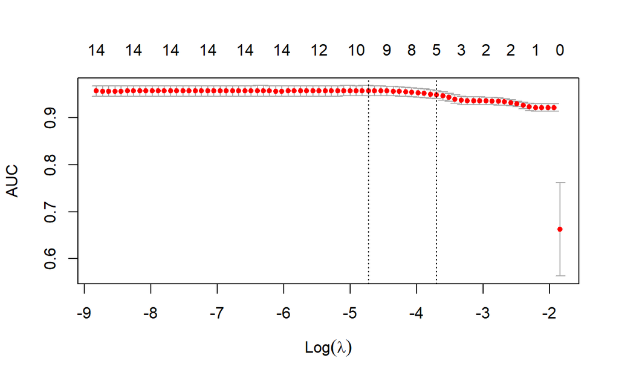

```r
set.seed(200)                                          # Seed 고정 -> 동일한 결과를 출력하기 위해
cv.lasso.fit <- cv.glmnet(x = train.x,                 # 예측 변수를 포함하는 행렬
                          y = UB.trd$Personal.Loan,    # Target
                          family = "binomial",         # Binary Classification
                          alpha = 1,                   # 0 : Ridge / 1 : Lasso / 0 < alpha < 1 : Elastic Net
                          nfolds = 5,                  # 5-Fold Cross Validation
                          type.measure = "auc")        # AUC에 기반하여 최적의 람다 값 찾기
plot(cv.lasso.fit)                                     # Plot
```

```r
cv.lasso.fit$lambda.min                                   # 최적의 람다 값
```

```
[1] 0.008899748
```

```r
max(cv.lasso.fit$cvm)                                     # 최적의 람다 값에 대한 AUC
```

```
[1] 0.958061
```

```r
round(coef(cv.lasso.fit, s = cv.lasso.fit$lambda.min), 3) # 최적의 람다 값에 대한 회귀계수 추정치
```

```
16 x 1 sparse Matrix of class "dgCMatrix"
                        s1
(Intercept)         -4.945
Age                  .
Experience           .
Income               1.812
ZIP.Code             .
Family2             -0.089
Family3              0.837
Family4              0.781
CCAvg                0.155
Education2           1.768
Education3           1.749
Mortgage             .
Securities.Account1  .
CD.Account1          2.170
Online1              .
CreditCard1         -0.281
```

`Result!` 최적의 $\lambda$ 값에 대해 추정된 회귀계수를 이용하여 다음과 같은 모형식을 얻을 수 있다.
$$\begin{align*}
\log{\frac{p}{1-p}} = &-4.945 +1.812 Z_{\text{Income}} -0.089 X_{\text{Family2}} + 0.837 X_{\text{Family3}} + 0.781 X_{\text{Family4}} \\
&+ 0.155 Z_{\text{CCAvg}} +1.768 X_{\text{Education2}} + 1.749 X_{\text{Education3}} + 2.170 X_{\text{CD.Account1}} -0.281 X_{\text{CreditCard1}}
\end{align*}$$

여기서, $Z_{\text{예측 변수}}$는 표준화한 예측 변수, $X_{\text{예측 변수}}$는 더미 변수를 의미한다.

# **7. 모형 평가**

`Caution!` 모형 평가를 위해 `Test Dataset`에 대한 `예측 class/확률` 이 필요하며, 함수 `predict()`를 이용하여 생성한다.

```r
# 예측 class 생성
test.lasso.class <- predict(cv.lasso.fit,
                            newx = test.x,                # Test Dataset including Only 예측 변수
                            s = "lambda.min",             # 최적의 람다 값 기반
                            type = "class")               # 예측 class 생성


test.lasso.class %>%
  as_tibble
```

```
# A tibble: 749 × 1
   lambda.min
   <chr>
 1 no
 2 no
 3 no
 4 no
 5 no
 6 no
 7 no
 8 no
 9 no
10 no
# ℹ 739 more rows
```

## **7-1. ConfusionMatrix**

```r
CM   <- caret::confusionMatrix(as.factor(test.lasso.class), UB.ted$Personal.Loan,
                               positive = "yes")       # confusionMatrix(예측 class, 실제 class, positive = "관심 class")
CM
```

```
Confusion Matrix and Statistics

          Reference
Prediction  no yes
       no  667  31
       yes   6  45

               Accuracy : 0.9506
                 95% CI : (0.9325, 0.965)
    No Information Rate : 0.8985
    P-Value [Acc > NIR] : 1.712e-07

                  Kappa : 0.6828

 Mcnemar's Test P-Value : 7.961e-05

            Sensitivity : 0.59211
            Specificity : 0.99108
         Pos Pred Value : 0.88235
         Neg Pred Value : 0.95559
             Prevalence : 0.10147
         Detection Rate : 0.06008
   Detection Prevalence : 0.06809
      Balanced Accuracy : 0.79159

       'Positive' Class : yes
```

## **7-2. ROC 곡선**

```r
# 예측 확률 생성
test.lasso.prob <- predict(cv.lasso.fit,
                           newx = test.x,              # Test Dataset including Only 예측 변수
                           s = "lambda.min",           # 최적의 람다 값 기반
                           type = "response")          # 예측 확률 생성


test.lasso.prob %>%                                    # "Personal.Loan = yes"에 대한 예측 확률
  as_tibble
```

```
# A tibble: 749 × 1
   lambda.min
        <dbl>
 1    0.00570
 2    0.0136
 3    0.00390
 4    0.00351
 5    0.0122
 6    0.0114
 7    0.0337
 8    0.0932
 9    0.121
10    0.0253
# ℹ 739 more rows
```

```r
ac  <- UB.ted$Personal.Loan                            # Test Dataset의 실제 class
pp  <- as.numeric(test.lasso.prob)                     # 예측 확률을 수치형으로 변환
```

### **1) Package “pROC”**

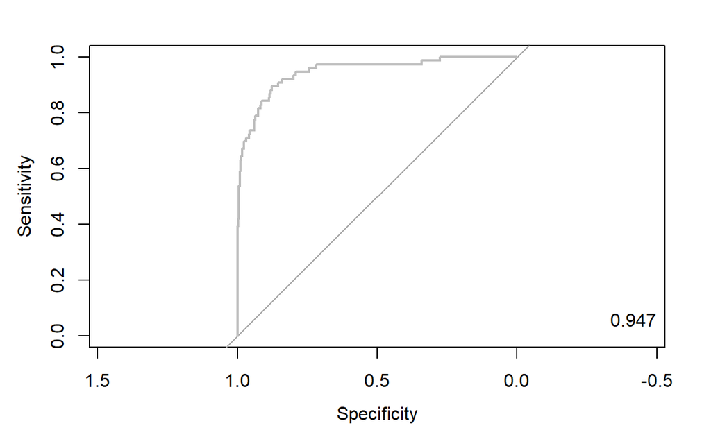

```r
pacman::p_load("pROC")

lasso.roc  <- roc(ac, pp, plot = T, col = "gray")      # roc(실제 class, 예측 확률)
auc        <- round(auc(lasso.roc), 3)
legend("bottomright", legend = auc, bty = "n")
```

`Caution!` Package `"pROC"`를 통해 출력한 ROC 곡선은 다양한 함수를 이용해서 그래프를 수정할 수 있다.

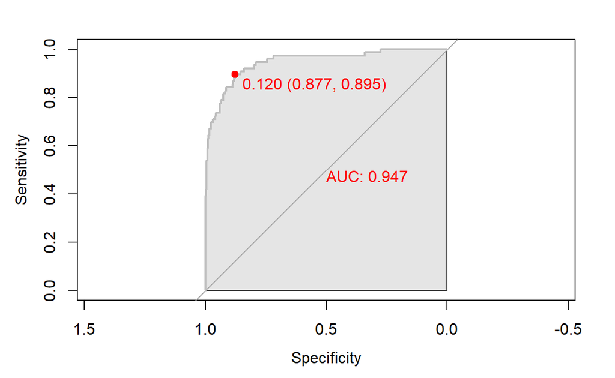

```r
# 함수 plot.roc() 이용
plot.roc(lasso.roc,
         col="gray",                                   # Line Color
         print.auc = TRUE,                             # AUC 출력 여부
         print.auc.col = "red",                        # AUC 글씨 색깔
         print.thres = TRUE,                           # Cutoff Value 출력 여부
         print.thres.pch = 19,                         # Cutoff Value를 표시하는 도형 모양
         print.thres.col = "red",                      # Cutoff Value를 표시하는 도형의 색깔
         auc.polygon = TRUE,                           # 곡선 아래 면적에 대한 여부
         auc.polygon.col = "gray90")                   # 곡선 아래 면적의 색깔
```

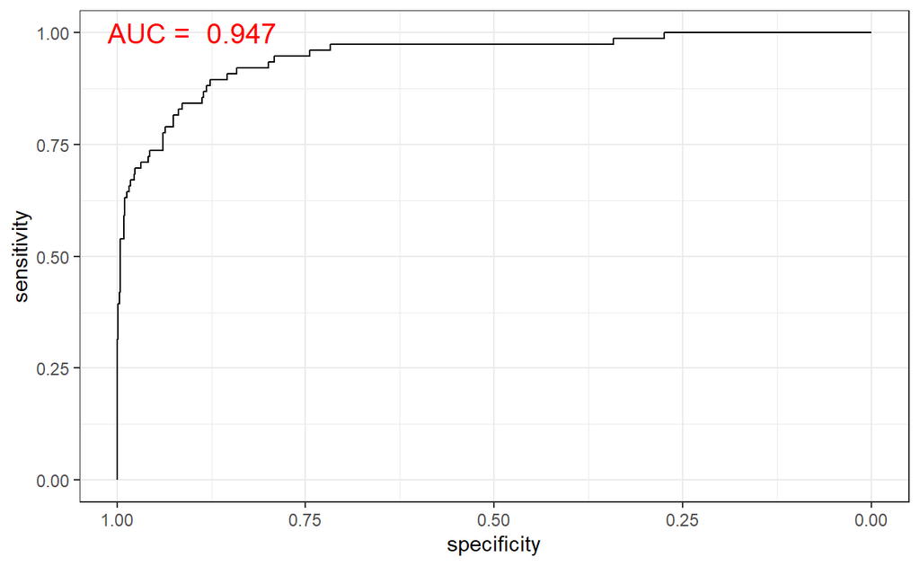

```r
# 함수 ggroc() 이용
ggroc(lasso.roc) +
annotate(geom = "text", x = 0.9, y = 1.0,
label = paste("AUC = ", auc),
size = 5,
color="red") +
theme_bw()
```

### **2) Package “Epi”**

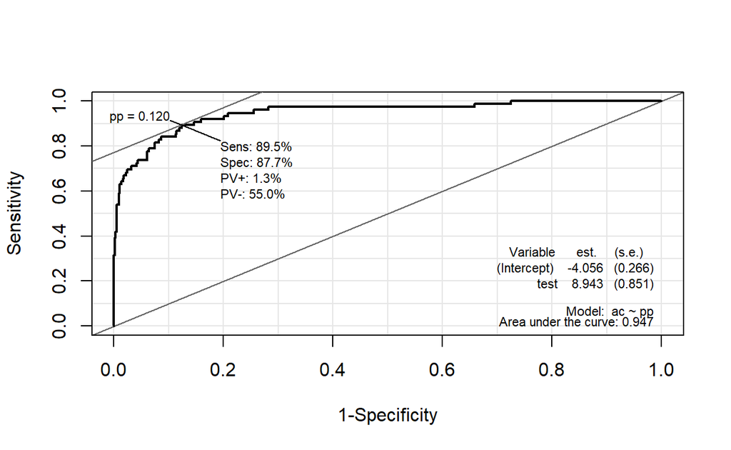

```r
pacman::p_load("Epi")
# install_version("etm", version = "1.1", repos = "http://cran.us.r-project.org")

ROC(pp, ac, plot = "ROC")                              # ROC(예측 확률, 실제 class)
```

### **3) Package “ROCR”**

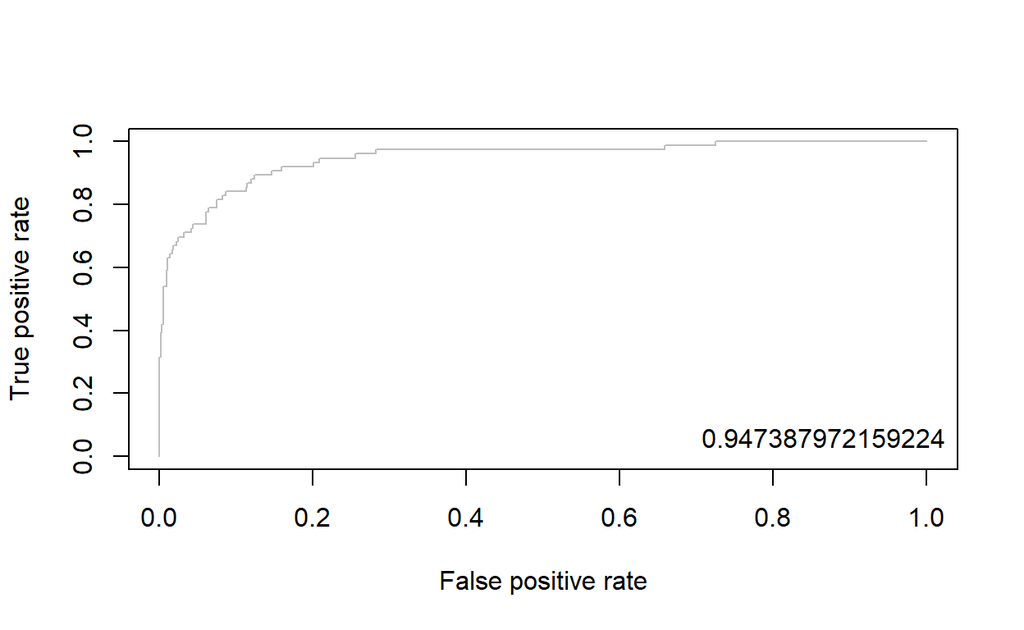

```r
pacman::p_load("ROCR")

lasso.pred <- prediction(pp, ac)                       # prediction(예측 확률, 실제 class)

lasso.perf <- performance(lasso.pred, "tpr", "fpr")    # performance(, "민감도", "1-특이도")
plot(lasso.perf, col = "gray")                         # ROC Curve

perf.auc   <- performance(lasso.pred, "auc")           # AUC
auc        <- attributes(perf.auc)$y.values
legend("bottomright", legend = auc, bty = "n")
```

## **7-3. 향상 차트**

### **1) Package “ROCR”**

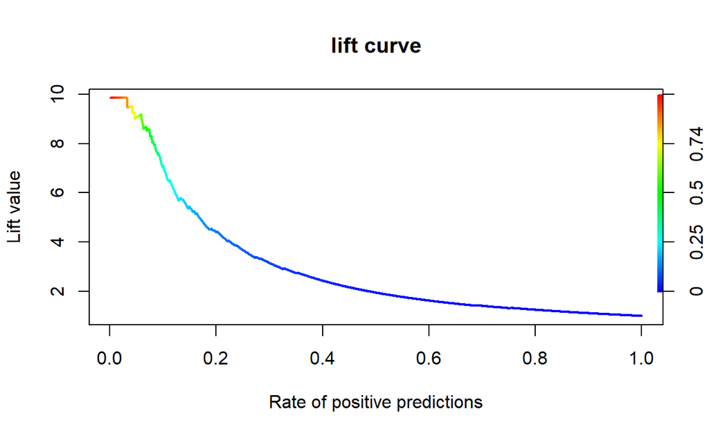

```r
lasso.perf <- performance(lasso.pred, "lift", "rpp")   # Lift Chart
plot(lasso.perf, main = "lift curve",
     colorize = T,                                     # Coloring according to cutoff
     lwd = 2)
```